# Time Series

In this blog we I will be walking you through how I form a time series graph using RStudio. To begin we will need to bring in the required packages using the library command:

```r
library(Lahman)
library(sqldf)
```

```r
library(ggplot2)
```

Step two is extracting the data. In this example we will be creating a time series of Babe Ruth’s total homeruns over his baseball career. We can collect this informating using an sqldf query search and storing the results in ‘result’ making it easy to apply to our graph later. Step three is visualizing the data by using ggplot(). A time series is slightky different because we need to use geom_point to make a scatter plot first, then use geom_line to connect the points and make the time series. We then use # to write out the points to make the graph my appealing. Note I added a title as well as x and y lables. For a time series graph the x variable is always the time.

```r
query<-"SELECT yearID,HR
FROM Batting
WHERE playerID='ruthba01'"

result<-sqldf(query)
```

Visualization———-

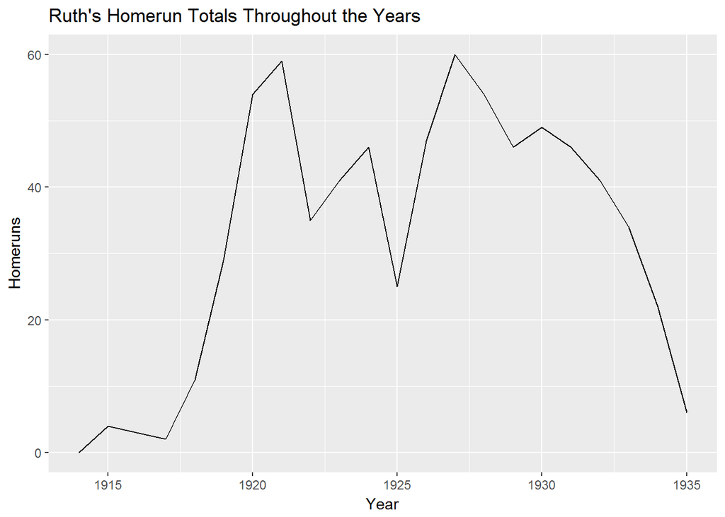

```r
ggplot()+
  #geom_point(data=result,aes(x=yearID,y=HR))+
  geom_line(data=result,aes(x=yearID,y=HR))+
  ggtitle("Ruth's Homerun Totals Throughout the Years")+
  xlab("Year")+
  ylab("Homeruns")
```